# Projekt 2 Faza 1

Patrycja Matys, Jan Rosa, Krzysztof Rutkowski, Magda Sobiczewska

17 maja 2016

## Wprowadzenie

Dokonaliśmy eksploracji danych zawierających liczbę przypadków raka piersi w Polsce w latach 2010, 2011, 2012 z podziałem na płeć, 6 kategorii wiekowych, faza choroby, kod TERYT/powiat, województwo. Wykorzystaliśmy również dane z GUS, aby pracować jedynie na znormalizowanych danych oraz bazy współrzędnych geograficznych z https://github.com/pbiecek/teryt, by wykreślić mapy Polski.

Dokonując synchronizacji wyjściowych danych z danymi GUS napotkaliśmy dwie rozbieżności. W GUS brak informacji na temat powiatu o kodzie TERYT 1431, stąd pominęliśmy ten powiat w eksploracji oraz w danych wyjściowych brakuje kodu TERYT 0265 (miasto Wałbrzych), który występuje w GUS, zatem włączyliśmy dane GUS o TERYT 0265 do powiatu wałbrzyskiego o kodzie 0221. Ostatecznie rozpatrujemy 379 powiatów.

Na wstępie szukaliśmy poziomów danych interesujących statystycznie i w dalszej części raportu będziemy pracować tylko na tych najbardziej interesujących.

## Hipoteza badawcza

Naszym głównym celem była szeroka eksploracja danych i znalezienie czynników, które wpływają na rozmieszczenie raka piersi w całej Polsce.

## Analiza czynników wpływająych na liczbę zachorowań

### Płeć

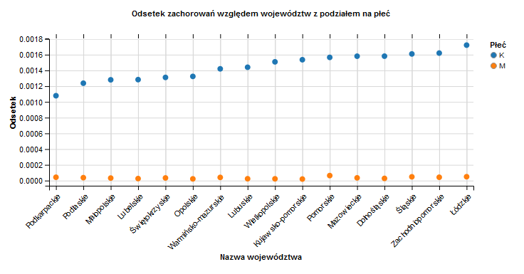

Z powyższego wykresu widzimym, że odsetki dla mężczyzn w podziale na województwa są niewielkie i równomiernie rozłożone, czego też mogliśmy się spodziewać patrząc na typ raka. Zatem dalej będziemy pracować z jedną płcią - kobietami.

### Grupa wiekowa

Na poniższym wykresie widzimy, że rozkład grup wiekowych w zależności od województwa jest zbliżony w obrębie całej Polski. Najwięcej osób choruje w średnim wieku - między 55 a 64 lat.

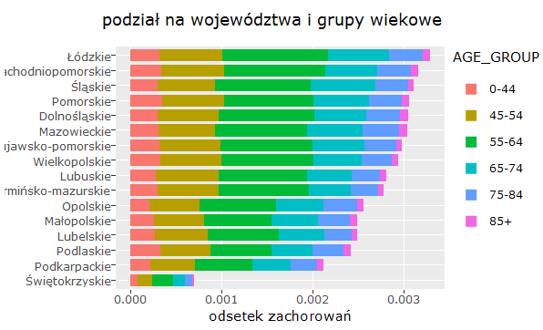

### Faza choroby

Na poniższym wykresie widzimy, że również rozkład różnych faz choroby w zależności od województwa jest zbliżony w obrębie całej Polski. Najwięcej wykrywa się w w 2 fazie.

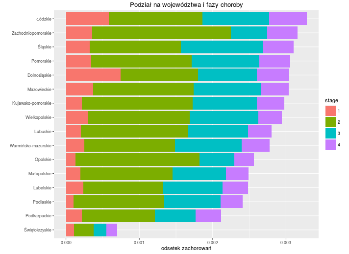

Pokazaliśmy, że rozkład grup wiekowych i faz nie jest istonie ważny ze względu na kryteria geograficzne i jest zbliżony w obrębie całej Polski. Dalej będziemy pracować na danych zsumowanych zarówno względem faz i wieku.

### Województwo

Na poniższej mapce widać, wyraźny podział zachorowań z względu na województwa. Widzimy wyraźną dysproporcję między np sąsiadującymi województwami Świętokrzyskim i Łódzkim.

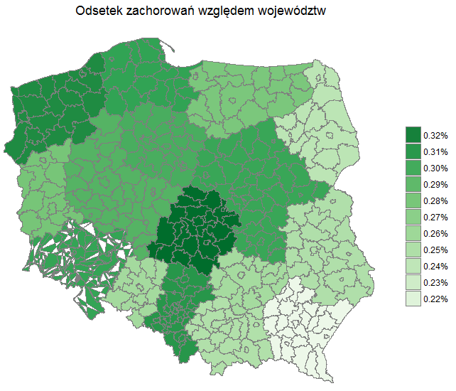

### Powiat

Gdy jednak zobaczymy na mapkę dla powiatów, nie widzimy już tak wyraźnej różnicy jeśli chodzi o województwa, między np Łódzkim i Świętokrzyskim nie widać wyraźnej dysproporcji na tle powiatów. Widać wyraźnie, że dominującymi powiatami są duże miasta i to one znacząco wpływają na województwo.

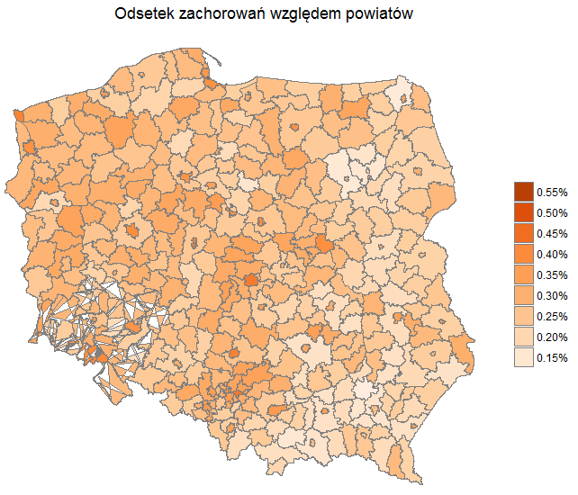

Spójrzmy teraz na 15 powiatów, w których odsetek zachorowań jest największy. Są wśród nich głównie duże miasta przemysłowe.

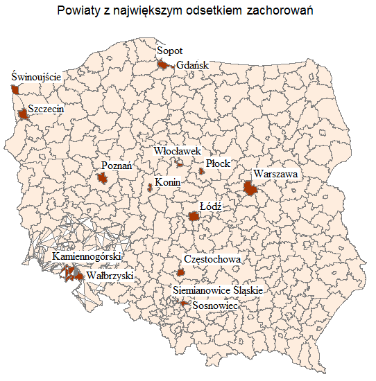

## Analiza rozkładu zachorowań powiatów względem województw

Z powyższych mapek widzimy, że dominujący wpływ na odsetek zachorowań w danym województwie mają duże miasta (głównie przemysłowe). Przyjrzeliśmy się jak wygląda rozkład odsetka zachorowań w powiatach w każdym województwie. I tu wyrózniliśmy dwie grupy - województwa nie posiadające dużego miasta przemysłowego - jak Świętokrzyskie czy Lubuskie, gdzie nie było wyraźnego dominatora, jak i województwa z wyraźnym dominatorem - miastem, które wybijało się ponad inne powiaty.

### Województwa bez większego miasta

W poniższych województwach mamy mały odsetek zachorowań, ale nie ma większego miasta, które wpływałoby na odsetek zachorowań. Największe odsetki zachorowań mają powiaty, które nie są miastami.

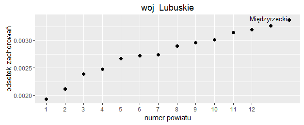

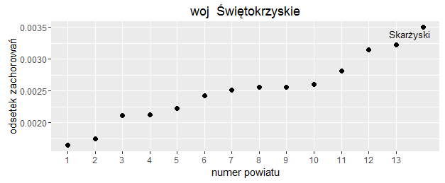

### Województwa z większym miastem

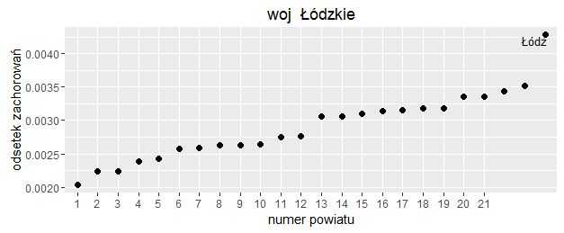

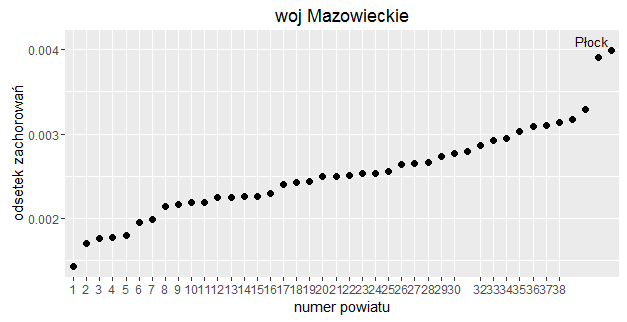

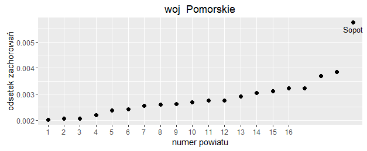

## Podsumowanie

Z poniższych analiz można wywnioskować, że ważnym czynnikiem wpływającym na liczbę zachorowań jest wiek, jednak ten czynnik nie jest uwarunkowany geograficznie. Dominującym czynnikiem geograficznym wpływającym na liczbę zachorowań jest podział duże miasto przemysłowe - inny powiat. Ten podział wydaje się dużo bardziej zasadny niż kryterium np województwa.